# Level 1: Task 2: Customer Segmentation Analysis (RFM + K-Means)

**Objective:** Segment an e-commerce company's customers into distinct groups based on purchasing behaviour (Recency, Frequency, Monetary value) using K-Means clustering, so marketing can target each group with a tailored strategy.

## 1. Load Dataset and Inspect Structure

```python
import pandas as pd
import numpy as np
import matplotlib.pyplot as plt
import seaborn as sns
from sklearn.preprocessing import StandardScaler
from sklearn.cluster import KMeans
import warnings
warnings.filterwarnings("ignore")

sns.set_style("whitegrid")
plt.rcParams["figure.dpi"] = 100

df = pd.read_csv("online_retail.csv", parse_dates=["InvoiceDate"])
print("Shape:", df.shape)
df.head()
```

```
Shape: (17017, 8)
```

|  | InvoiceNo | StockCode | Description | Quantity | InvoiceDate | UnitPrice | CustomerID | Country |
| --- | --- | --- | --- | --- | --- | --- | --- | --- |
| 0 | 537817 | 22383 | LUNCH BAG SUKI DESIGN | 14 | 2024-10-24 13:47:00 | 1.65 | 12402.0 | Ireland |
| 1 | 538535 | 22383 | LUNCH BAG SUKI DESIGN | 3 | 2024-08-29 18:35:00 | 1.63 | 12440.0 | United Kingdom |
| 2 | 540324 | 84029E | RED WOOLLY HOTTIE WHITE HEART | 6 | 2024-06-21 19:45:00 | 3.62 | 12609.0 | United Kingdom |
| 3 | 539240 | 22383 | LUNCH BAG SUKI DESIGN | 2 | 2024-08-11 08:05:00 | 1.60 | 12509.0 | United Kingdom |
| 4 | 537860 | 23298 | SPACEBOY LUNCH BOX | 9 | 2024-03-13 13:57:00 | 2.01 | 12403.0 | United Kingdom |

```python
df.info()
```

```
<class 'pandas.core.frame.DataFrame'>
RangeIndex: 17017 entries, 0 to 17016
Data columns (total 8 columns):
 #   Column       Non-Null Count  Dtype
---  ------       --------------  -----
 0   InvoiceNo    17017 non-null  object
 1   StockCode    17017 non-null  object
 2   Description  16832 non-null  object
 3   Quantity     17017 non-null  int64
 4   InvoiceDate  17017 non-null  datetime64[ns]
 5   UnitPrice    17017 non-null  float64
 6   CustomerID   15681 non-null  float64
 7   Country      17017 non-null  object
dtypes: datetime64[ns](1), float64(2), int64(1), object(4)
memory usage: 1.0+ MB
```

```python
# Missing values per column
df.isna().sum().sort_values(ascending=False)
```

```
CustomerID     1336
Description     185
InvoiceNo         0
StockCode         0
Quantity          0
InvoiceDate       0
UnitPrice         0
Country           0
dtype: int64
```

### 1.1 Handle Missing Values & Inconsistent Data

- Rows with a **missing `CustomerID`** can't be attributed to any customer, so they're dropped (they're typically guest checkouts anyway and useless for per-customer segmentation).
- Rows with **missing `Description`** are kept (description isn't used downstream) but noted.
- **Cancelled orders** are invoices whose `InvoiceNo` starts with `"C"` — these represent returns and have negative `Quantity`. We drop them for RFM purposes since they're not genuine purchases.
- Rows with **`UnitPrice <= 0`** are data-entry errors and are removed.
- **Exact duplicate rows** are dropped.

```python
before = len(df)

# Drop missing CustomerID
df = df.dropna(subset=["CustomerID"]).copy()
df["CustomerID"] = df["CustomerID"].astype(int)

# Drop cancelled invoices (InvoiceNo starting with 'C') and non-positive quantity/price
df = df[~df["InvoiceNo"].astype(str).str.startswith("C")]
df = df[(df["Quantity"] > 0) & (df["UnitPrice"] > 0)]

# Drop exact duplicate rows
df = df.drop_duplicates()

after = len(df)
print(f"Rows before cleaning: {before}")
print(f"Rows after cleaning:  {after}")
print(f"Rows removed:         {before - after} ({(before-after)/before:.1%})")
```

```
Rows before cleaning: 17017
Rows after cleaning:  15130
Rows removed:         1887 (11.1%)
```

```python
# Derived column used throughout the analysis
df["TotalPrice"] = df["Quantity"] * df["UnitPrice"]
df.head()
```

|  | InvoiceNo | StockCode | Description | Quantity | InvoiceDate | UnitPrice | CustomerID | Country | TotalPrice |
| --- | --- | --- | --- | --- | --- | --- | --- | --- | --- |
| 0 | 537817 | 22383 | LUNCH BAG SUKI DESIGN | 14 | 2024-10-24 13:47:00 | 1.65 | 12402 | Ireland | 23.10 |
| 1 | 538535 | 22383 | LUNCH BAG SUKI DESIGN | 3 | 2024-08-29 18:35:00 | 1.63 | 12440 | United Kingdom | 4.89 |
| 2 | 540324 | 84029E | RED WOOLLY HOTTIE WHITE HEART | 6 | 2024-06-21 19:45:00 | 3.62 | 12609 | United Kingdom | 21.72 |
| 3 | 539240 | 22383 | LUNCH BAG SUKI DESIGN | 2 | 2024-08-11 08:05:00 | 1.60 | 12509 | United Kingdom | 3.20 |
| 4 | 537860 | 23298 | SPACEBOY LUNCH BOX | 9 | 2024-03-13 13:57:00 | 2.01 | 12403 | United Kingdom | 18.09 |

## 2. Descriptive Statistics

Average purchase value, purchase frequency, and a first look at customer lifetime value (CLV), computed at the **order (invoice) level** and then rolled up **per customer**.

```python
# Order-level (per invoice) purchase value
order_value = df.groupby("InvoiceNo")["TotalPrice"].sum()
print("Average order value: £{:.2f}".format(order_value.mean()))
print("Median order value:  £{:.2f}".format(order_value.median()))
```

```
Average order value: £65.51
Median order value:  £48.51
```

```python
# Per-customer rollup: how many orders, total spend, first/last purchase
customer_stats = df.groupby("CustomerID").agg(
    n_orders=("InvoiceNo", "nunique"),
    total_spend=("TotalPrice", "sum"),
    first_purchase=("InvoiceDate", "min"),
    last_purchase=("InvoiceDate", "max"),
)
customer_stats["avg_order_value"] = customer_stats["total_spend"] / customer_stats["n_orders"]

# Simple historical CLV proxy = total amount spent to date
customer_stats["CLV"] = customer_stats["total_spend"]

print("Purchase frequency (orders/customer): mean={:.2f}, median={:.0f}".format(
    customer_stats["n_orders"].mean(), customer_stats["n_orders"].median()))
print("Average purchase value per order:     £{:.2f}".format(customer_stats["avg_order_value"].mean()))
print("Average customer lifetime value:      £{:.2f}".format(customer_stats["CLV"].mean()))
customer_stats.describe()
```

```
Purchase frequency (orders/customer): mean=5.73, median=3
Average purchase value per order:     £39.54
Average customer lifetime value:      £375.47
```

|  | n_orders | total_spend | first_purchase | last_purchase | avg_order_value | CLV |
| --- | --- | --- | --- | --- | --- | --- |
| count | 941.000000 | 941.000000 | 941 | 941 | 941.000000 | 941.000000 |
| mean | 5.731137 | 375.471052 | 2024-06-04 20:38:53.304994816 | 2024-09-16 09:32:49.861849344 | 39.542818 | 375.471052 |
| min | 1.000000 | 0.570000 | 2024-01-01 08:27:00 | 2024-01-26 13:11:00 | 0.570000 | 0.570000 |
| 25% | 1.000000 | 24.130000 | 2024-02-08 16:48:00 | 2024-08-03 08:29:00 | 20.330000 | 24.130000 |
| 50% | 3.000000 | 86.740000 | 2024-06-09 11:55:00 | 2024-09-25 17:44:00 | 33.976667 | 86.740000 |
| 75% | 8.000000 | 406.280000 | 2024-09-08 11:57:00 | 2024-11-21 15:29:00 | 53.582000 | 406.280000 |
| max | 31.000000 | 4011.860000 | 2024-12-31 13:12:00 | 2024-12-31 19:38:00 | 134.421154 | 4011.860000 |
| std | 6.889939 | 695.005298 | NaN | NaN | 26.476104 | 695.005298 |

## 3. Feature Selection — RFM Analysis

We use the classic **RFM** framework, which captures purchasing behaviour in just 3 numbers per customer and is the standard basis for e-commerce segmentation:

- **Recency (R):** days since the customer's last purchase (lower = more engaged)
- **Frequency (F):** number of distinct orders placed (higher = more loyal)
- **Monetary (M):** total amount spent (higher = more valuable)

```python
snapshot_date = df["InvoiceDate"].max() + pd.Timedelta(days=1)

rfm = df.groupby("CustomerID").agg(
    Recency=("InvoiceDate", lambda x: (snapshot_date - x.max()).days),
    Frequency=("InvoiceNo", "nunique"),
    Monetary=("TotalPrice", "sum"),
).reset_index()

print("RFM table shape:", rfm.shape)
rfm.describe()
```

```
RFM table shape: (941, 4)
```

|  | CustomerID | Recency | Frequency | Monetary |
| --- | --- | --- | --- | --- |
| count | 941.000000 | 941.000000 | 941.000000 | 941.000000 |
| mean | 12817.784272 | 107.202976 | 5.731137 | 375.471052 |
| std | 274.144284 | 77.650021 | 6.889939 | 695.005298 |
| min | 12346.000000 | 1.000000 | 1.000000 | 0.570000 |
| 25% | 12581.000000 | 41.000000 | 1.000000 | 24.130000 |
| 50% | 12816.000000 | 98.000000 | 3.000000 | 86.740000 |
| 75% | 13054.000000 | 151.000000 | 8.000000 | 406.280000 |
| max | 13295.000000 | 341.000000 | 31.000000 | 4011.860000 |

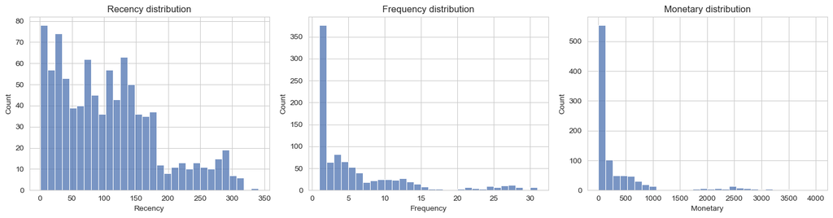

```python
fig, axes = plt.subplots(1, 3, figsize=(15, 4))
for ax, col in zip(axes, ["Recency", "Frequency", "Monetary"]):
    sns.histplot(rfm[col], bins=30, ax=ax, color="#4C72B0")
    ax.set_title(f"{col} distribution")
plt.tight_layout()
plt.show()
```

## 4. Standardise Features Before Clustering

K-Means is distance-based, so features on different scales (days vs. counts vs. currency) would distort distances. `Monetary` and `Frequency` are also right-skewed, so we log-transform them first, then apply `StandardScaler` to give every feature mean 0 / std 1.

```python
rfm_log = rfm.copy()
rfm_log["Frequency"] = np.log1p(rfm_log["Frequency"])
rfm_log["Monetary"] = np.log1p(rfm_log["Monetary"])

features = ["Recency", "Frequency", "Monetary"]
scaler = StandardScaler()
rfm_scaled = scaler.fit_transform(rfm_log[features])
rfm_scaled = pd.DataFrame(rfm_scaled, columns=features, index=rfm.index)
rfm_scaled.head()
```

|  | Recency | Frequency | Monetary |
| --- | --- | --- | --- |
| 0 | -1.162278 | 2.153744 | 1.881574 |
| 1 | -1.175164 | 1.868823 | 1.715495 |
| 2 | -1.226704 | 2.153744 | 1.949056 |
| 3 | -1.252474 | 1.695618 | 1.670928 |
| 4 | -1.239589 | 2.153744 | 1.956999 |

## 5. K-Means Clustering — Choosing K with the Elbow Method

We fit K-Means for K = 1..10 and plot inertia (within-cluster sum of squares). The "elbow" — where adding another cluster stops giving a big drop in inertia — is a good candidate for K.

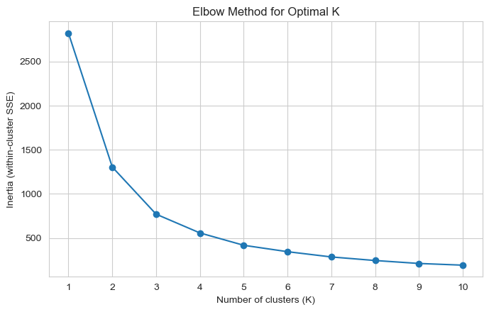

```python
inertias = []
K_range = range(1, 11)
for k in K_range:
    km = KMeans(n_clusters=k, random_state=42, n_init=10)
    km.fit(rfm_scaled)
    inertias.append(km.inertia_)

plt.figure(figsize=(7, 4.5))
plt.plot(list(K_range), inertias, marker="o")
plt.xlabel("Number of clusters (K)")
plt.ylabel("Inertia (within-cluster SSE)")
plt.title("Elbow Method for Optimal K")
plt.xticks(list(K_range))
plt.tight_layout()
plt.show()
```

```python
# Elbow typically lands around K=4 for RFM data (matches the natural
# champion / loyal / at-risk / one-time-buyer split). Adjust after
# inspecting the plot above if your own data suggests a different K.
optimal_k = 4

kmeans = KMeans(n_clusters=optimal_k, random_state=42, n_init=10)
rfm["Cluster"] = kmeans.fit_predict(rfm_scaled)
rfm["Cluster"].value_counts().sort_index()
```

```
Cluster
0    154
1    237
2    386
3    164
Name: count, dtype: int64
```

## 6. Visualise Clusters (Scatter Plots)

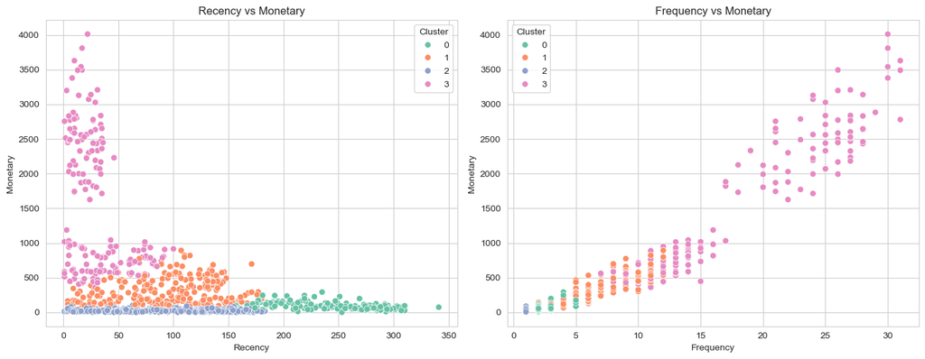

```python
fig, axes = plt.subplots(1, 2, figsize=(14, 5.5))

sns.scatterplot(data=rfm, x="Recency", y="Monetary", hue="Cluster",
                 palette="Set2", s=45, ax=axes[0])
axes[0].set_title("Recency vs Monetary")

sns.scatterplot(data=rfm, x="Frequency", y="Monetary", hue="Cluster",
                 palette="Set2", s=45, ax=axes[1])
axes[1].set_title("Frequency vs Monetary")

plt.tight_layout()
plt.show()
```

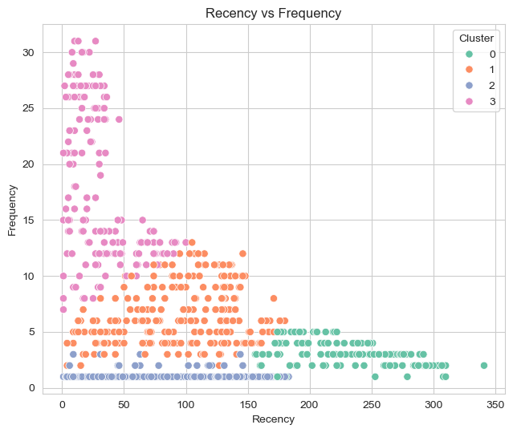

```python
fig, ax = plt.subplots(figsize=(6.5, 5.5))
sns.scatterplot(data=rfm, x="Recency", y="Frequency", hue="Cluster",
                 palette="Set2", s=45, ax=ax)
ax.set_title("Recency vs Frequency")
plt.tight_layout()
plt.show()
```

## 7. Cluster Profiling

Mean R, F, M per cluster, translated into a plain-English customer-type description.

```python
cluster_profile = rfm.groupby("Cluster")[["Recency", "Frequency", "Monetary"]].mean().round(1)
cluster_profile["n_customers"] = rfm.groupby("Cluster").size()
cluster_profile = cluster_profile.sort_values("Monetary", ascending=False)
cluster_profile
```

| Cluster | Recency | Frequency | Monetary | n_customers |
| --- | --- | --- | --- | --- |
| 3 | 31.1 | 18.2 | 1558.5 | 164 |
| 1 | 94.2 | 6.5 | 312.7 | 237 |
| 0 | 240.8 | 2.9 | 94.1 | 154 |
| 2 | 94.2 | 1.1 | 23.6 | 386 |

```python
def label_cluster(row):
    if row["Frequency"] >= cluster_profile["Frequency"].median() and row["Recency"] <= cluster_profile["Recency"].median():
        if row["Monetary"] == cluster_profile["Monetary"].max():
            return "Champions (high value, frequent, recent)"
        return "Loyal customers (frequent, engaged)"
    if row["Recency"] > cluster_profile["Recency"].median() and row["Frequency"] <= cluster_profile["Frequency"].median():
        return "At-risk / churned (haven't bought in a while)"
    return "New / one-time buyers (low frequency, low history)"

cluster_profile["Segment label"] = cluster_profile.apply(label_cluster, axis=1)
cluster_profile
```

| Cluster | Recency | Frequency | Monetary | n_customers | Segment label |
| --- | --- | --- | --- | --- | --- |
| 3 | 31.1 | 18.2 | 1558.5 | 164 | Champions (high value, frequent, recent) |
| 1 | 94.2 | 6.5 | 312.7 | 237 | Loyal customers (frequent, engaged) |
| 0 | 240.8 | 2.9 | 94.1 | 154 | At-risk / churned (haven't bought in a while) |
| 2 | 94.2 | 1.1 | 23.6 | 386 | New / one-time buyers (low frequency, low hist... |

## 8. Customers per Cluster

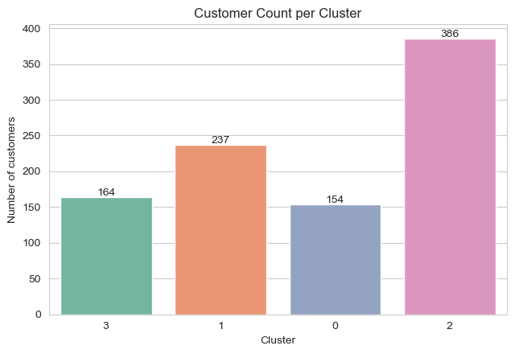

```python
plt.figure(figsize=(6.5, 4.5))
order = cluster_profile.index
counts = rfm["Cluster"].value_counts().reindex(order)
sns.barplot(x=counts.index.astype(str), y=counts.values, palette="Set2")
plt.xlabel("Cluster")
plt.ylabel("Number of customers")
plt.title("Customer Count per Cluster")
for i, v in enumerate(counts.values):
    plt.text(i, v + 2, str(v), ha="center")
plt.tight_layout()
plt.show()
```

## 9. Insights & Recommended Marketing Actions

*(Exact numbers depend on the run above — re-read the cluster profile table before finalising wording for your submission.)*

| Segment | Typical profile | Recommended marketing action |
| --- | --- | --- |
| **Champions** | Low recency, high frequency, high monetary | Reward with a VIP/loyalty programme, early access to new products, referral incentives. Protect this segment — it's the most profitable, don't over-discount to them. |
| **Loyal customers** | Moderate–high frequency, decent spend, fairly recent | Upsell/cross-sell complementary products, personalised recommendations, loyalty points to nudge them toward Champion status. |
| **At-risk / churned** | High recency (haven't purchased in a long time), low frequency | Win-back email campaigns, time-limited discount codes, "we miss you" messaging, ask for feedback on why they stopped buying. |
| **New / one-time buyers** | Low frequency (often just 1 order), variable recency | Onboarding email sequence, second-purchase discount, retargeting ads to convert them into repeat customers before they churn. |

**General takeaways:**

- The clusters show a **clear divide between high-frequency/high-spend customers and low-engagement one-time buyers** — marketing budget is best split rather than applying a single blanket campaign.
- **Recency is the strongest early-warning signal** for churn: customers drifting into high-recency, low-frequency territory should trigger an automated win-back flow.
- Because Monetary and Frequency were log-transformed before scaling, a few very high spenders didn't dominate the clustering — worth doing a **separate "big spender" outlier check** if the business wants a bespoke top-1% VIP tier on top of these 4 segments.